# Linear regression Lab

Andrea Sánchez-Tapia , Paulinha Lemos-Costa  
2023-01-13

# Simple linear models

Linear regressions in R assume a linear relationship between one or more predictor variables $X_i$ and a response variable $Y$.

$$y_i \sim \mathcal{N}(\mu_i, \sigma) \\
\mu_i = \beta_0 + \beta_1 x_i$$

The first element of this model describes how the response variable $Y$ can be modeled as a normal random variable with mean and standard deviation.

The second element of this model adds the effect of the predictor variable $X$ on $Y$, based on the causal relationship $X \rightarrow Y$. In this simple case, the relationship is linear and can be described by the equation of a line with intercept $\beta_0$ and slope $\beta_1$.

## Generating the dataset

In the introductory lecture for linear models, we used an example dataset to fit a simple regression model.

*The dataset itself was generated according to the specifications of the model above*. We are going to recreate the dataset and some of the calculations presented during the class.

```r
set.seed(4) #ensures the result is reproducible. The random number generation can vary between Operative systems so maybe there will be different datasets in the classroom
x_i <- seq(1, 5, by = 0.5)
n <- length(x_i)
mu <- 1.2 + 3.5 * x_i
y_i <- rnorm(n = 9, mean = mu, sd = 3)
lm_data <- data.frame(x_i,  mu, y_i, res = y_i - mu)
```

Create a plot for the dataset

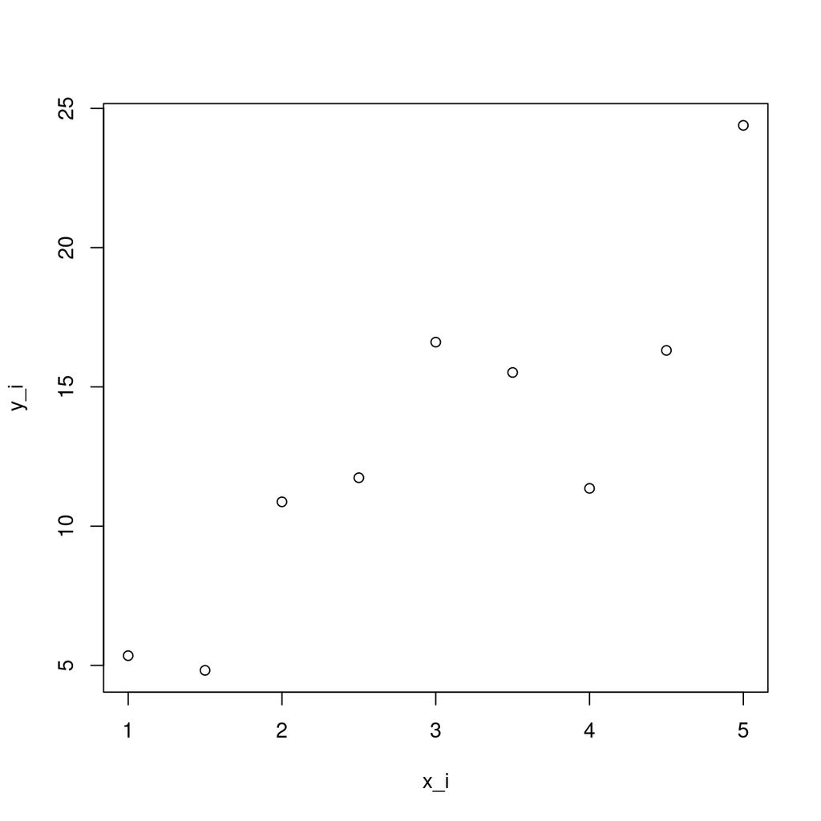

```r
plot(y_i ~ x_i)
```

As you can see, plotting the data suggests a linear relationship between these two variables

## Regression coefficients

Let’s calculate the coefficients for the regression line according to the Ordinal Least Squares method:

$$\widehat{\beta_1}=\frac{\sum_{i=1}^{n}(x_i-\bar{x})(y_i-\bar{y})}{\sum_{i=1}^{n}(x_i-\bar{x})^2}$$

and

$$\hat{\beta_0} = \bar{y} - \hat{\beta_1}\bar{x}$$

```r
x <- x_i
y <- y_i
beta1_hat <- sum((x - mean(x)) * (y - mean(y))) / sum((x - mean(x)) ^ 2)
beta1_hat
```

```
[1] 3.84557
```

```r
# Since mu = beta0 + beta1(X):
beta0_hat <- mean(y) - beta1_hat * mean(x)
beta0_hat
```

```
[1] 1.459434
```

Add a regression line with the values of the coefficients you calculated

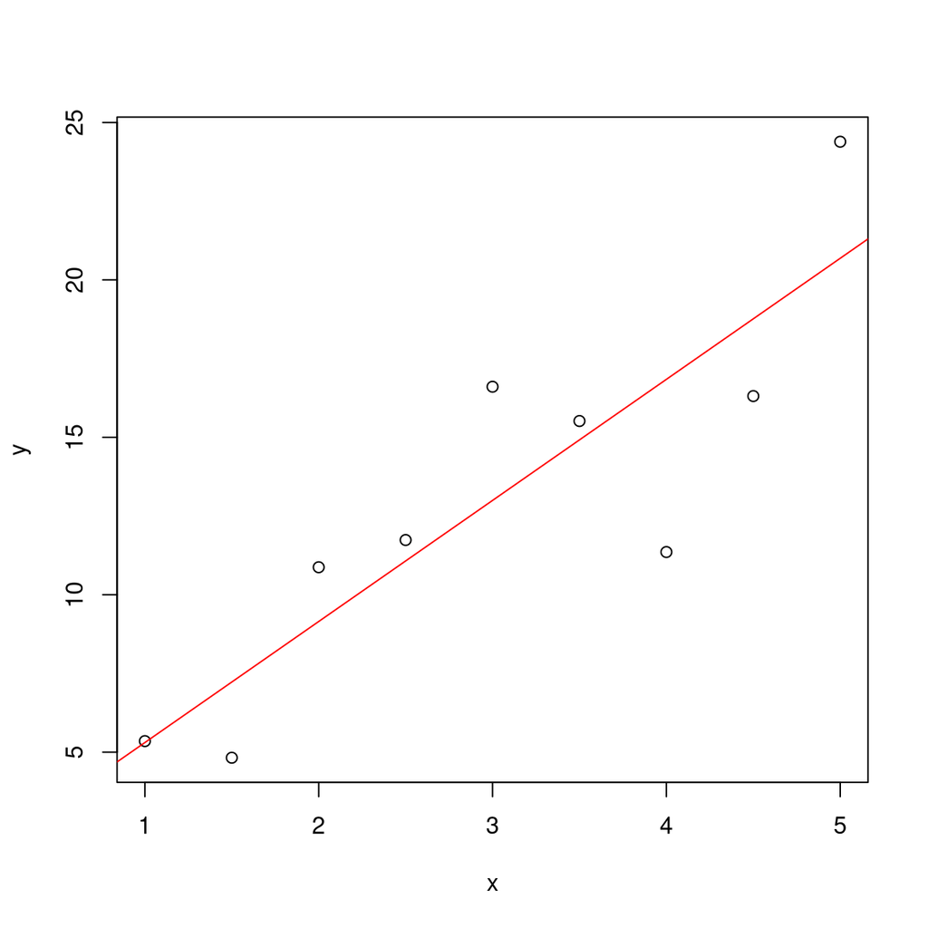

```r
plot(y ~ x)
abline(a = beta0_hat, b = beta1_hat, col = "red")
```

## The sample is not the population

When we generated the dataset (here), $\mu$ was specified as:

```r
mu <- 1.2 + 3.5 * x_i
```

This means $\beta_0 = 1.2$ and $\beta_1 = 3.5$. How do these values compare to the coefficients you just calculated?

Add a population line to the plot you previously created by completing the code below:

```r
plot(y ~ x)
abline(a = beta0_hat, b = beta1_hat, col = "red")
abline(a = ..., b = ..., col = "blue")
```

See the code by clicking **Show code**:

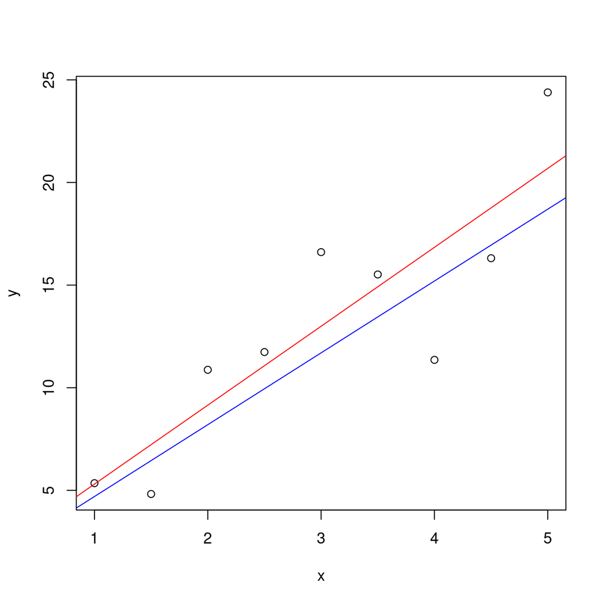

```r
plot(y ~ x)
abline(a = beta0_hat, b = beta1_hat, col = "red")
abline(a = 1.2, b = 3.5, col = "blue")
```

## Fitting a linear model in R

Function `lm()` fits regression models using Ordinal Least Squares. The values of the coefficients can be found using function `coef()`.

```r
mod <- lm(y ~ x)
coef(mod)
```

```
(Intercept)           x
   1.459434    3.845570
```

Compare this result with the calculations you did previously.

### Let’s do the calculations for Sums of squares, residual sum of squares and Sums of squares of the regression

$SS_y$, $RSS$, and $SS_{Reg}$

$$RSS = \sum_{i=1}^{n}(y_i-\hat{y}_i)^2$$

$SS_y = {\sum_{i=1}^{n}(y_i-\bar{y})^2}$

$$SS_Y = SS_{Reg} + RSS$$